# Introduction to AIC-based Model Selection using polynomials

Andrew L Jackson

24 November 2015

```r
# Start off with some house-keeping and set-up.

# load the viridis package for pretty and accessible colours especially for
# those with colour blindness. You will need to install this if you dont have it
# already using install.packages("viridis")
library(viridis)

# Here I create a palette of 8 colours from the viridis spectrum. I can then
# access these colours within plotting commands by e.g. plot(0,0, col = 1),
# or plot(0,0, col = 4) or plot(0,0, col = 8). This palette is also useful as it
# will print clearly in greyscale without any extra effort. See vignette for
# viridis for more details.
palette(viridis(8))
```

We are going to work with a simple dataset that comprises the species richness of fishing hauls (trawl fishing) of varying effort (time in minutes). These data are contained in the file `curved-data.csv`.

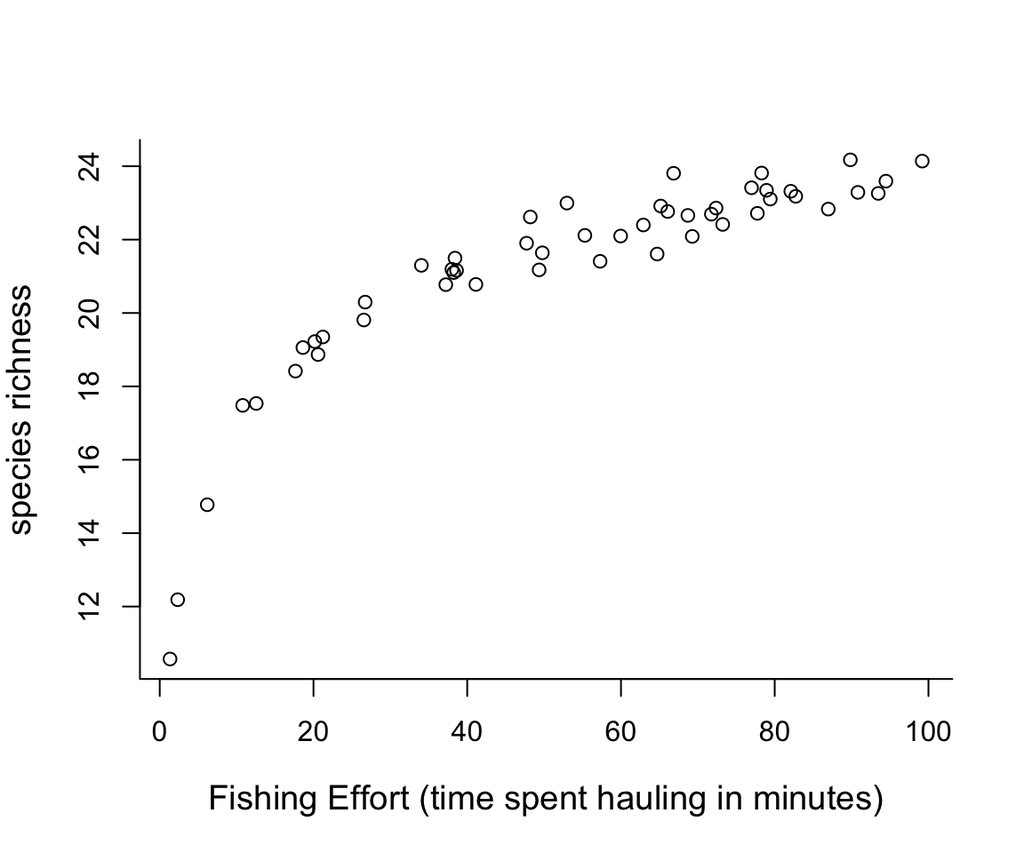

```r
mydata <- read.csv("curved-data.csv", header = T, stringsAsFactors = FALSE)

plot(richness ~ effort, data = mydata, bty = "L", cex.lab = 1.2,
     xlab = "Fishing Effort (time spent hauling in minutes)",
     ylab = "species richness")
```

The aim is to fit a set of polynomial models to the data and use AIC to identify the most parsimonious order polynomial. To get you started, we will first fit three models: the null model, a basic linear model, and a quadratic model. There after, you will fit higher order polynomials, compare their AIC and use the `predict` function to generate the esimated values for adding the fitted curves to the plot.

## The Null model (zero order polynomial)

The null model is the most simple linear model that we might fit to some data. It comprises only a mean and standard deviatoin (or variance depending on your preference) for the data. Mathematically it looks like $Y = \beta_0 + \epsilon$, where $\beta_0$ is the intercept and overall mean of the response variable $Y$ and $\epsilon$ is the error which is defined by a variance or standard deviation depending on your preference for notation.

The null model is specified by the function $Y \tilde 1$ where `1` represents the coefficient of the intercept which is always equal to `1` which is why we omit it from the equation $Y = \beta_0 * (1) + \epsilon$. We are going to get into the habit of using the `data =` argument when we call `glm()`. This approach basically creates a private environment within the function glm() where it can see inside the dataframe object `mydata` and access the columns of data without having to manually use the dollar sign notation `mydata$richness`. This is important for a subsequent step where we will use the `predict` function.

**Note** that I am now using functions within the `plot()` command in order to make use of the `data =` argument that follows. This also has the benefit of being consistent with how we specify the models in `glm()`.

```r
null.model <- glm(richness ~ 1, data = mydata)

summary(null.model)
```

```
#>
#> Call:
#> glm(formula = richness ~ 1, data = mydata)
#>
#> Deviance Residuals:
#>      Min        1Q    Median        3Q       Max
#> -10.6640   -0.4602    0.8585    1.7416    2.9395
#>
#> Coefficients:
#>             Estimate Std. Error t value Pr(>|t|)
#> (Intercept)  21.2339     0.3974   53.43   <2e-16 ***
#> ---
#> Signif. codes:  0 '***' 0.001 '**' 0.01 '*' 0.05 '.' 0.1 ' ' 1
#>
#> (Dispersion parameter for gaussian family taken to be 7.897574)
#>
#>     Null deviance: 386.98  on 49  degrees of freedom
#> Residual deviance: 386.98  on 49  degrees of freedom
#> AIC: 248.21
#>
#> Number of Fisher Scoring iterations: 2
```

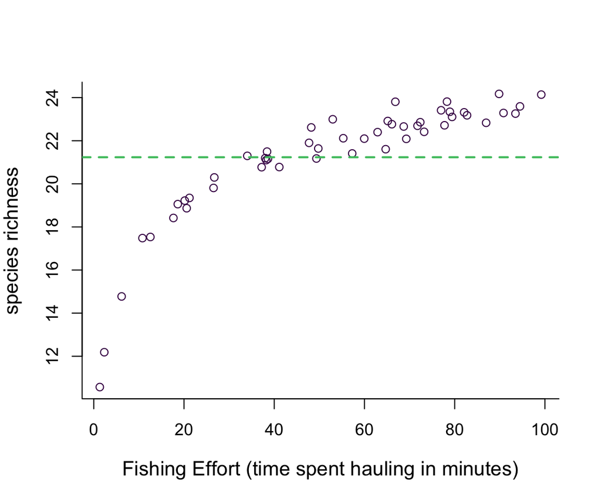

```r
# the null model is just a mean, so graphically it is a horizontal line,
# and ordinarily we would not bother to plot it, as it is pretty much
# utterly uniformative.
plot(richness ~ effort,
     data = mydata,
     bty = "L",
     cex.lab = 1.2,
     xlab = "Fishing Effort (time spent hauling in minutes)",
     ylab = "species richness",
     col = 1)

# use abline(h=) to add a horizontal line by extracting the intercept
# using coef() on the null.model object.
abline(h = coef(null.model) , col = 6, lty = 2, lwd = 2)
```

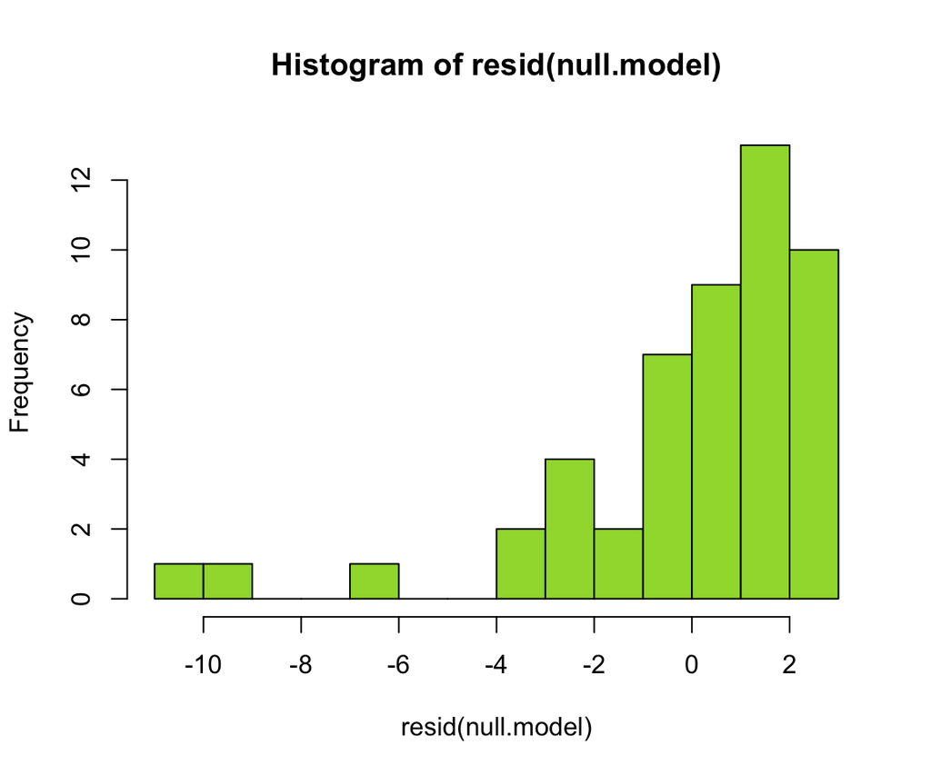

```r
# histogram of the residuals...
hist(resid(null.model), 15, col = 7)
```

It is important to note the AIC of this fitted model which is 248.2. There is no need to check the residuals of this fitted model beyond a simple histogram which shows that they are not normally distributed. Clearly the line does not explain the data well, and you can quickly determine that this is not a very good model of the data. This is hardly surprising though given how simple it is: on to more complicated models!

## Simple linear model (1st order polynomial)

We don’t expect a straight line model to be much better, but its still worth fitting it for completeness and by way of providing a comparison against which we can test a quadratic model in the next step.

```r
first.model <- glm(richness ~ effort, data = mydata)

summary(first.model)
```

```
#>
#> Call:
#> glm(formula = richness ~ effort, data = mydata)
#>
#> Deviance Residuals:
#>     Min       1Q   Median       3Q      Max
#> -6.0745  -0.5377   0.2789   0.9302   1.8294
#>
#> Coefficients:
#>              Estimate Std. Error t value Pr(>|t|)
#> (Intercept) 16.526004   0.459320   35.98  < 2e-16 ***
#> effort       0.088395   0.007695   11.49 2.23e-15 ***
#> ---
#> Signif. codes:  0 '***' 0.001 '**' 0.01 '*' 0.05 '.' 0.1 ' ' 1
#>
#> (Dispersion parameter for gaussian family taken to be 2.150445)
#>
#>     Null deviance: 386.98  on 49  degrees of freedom
#> Residual deviance: 103.22  on 48  degrees of freedom
#> AIC: 184.14
#>
#> Number of Fisher Scoring iterations: 2
```

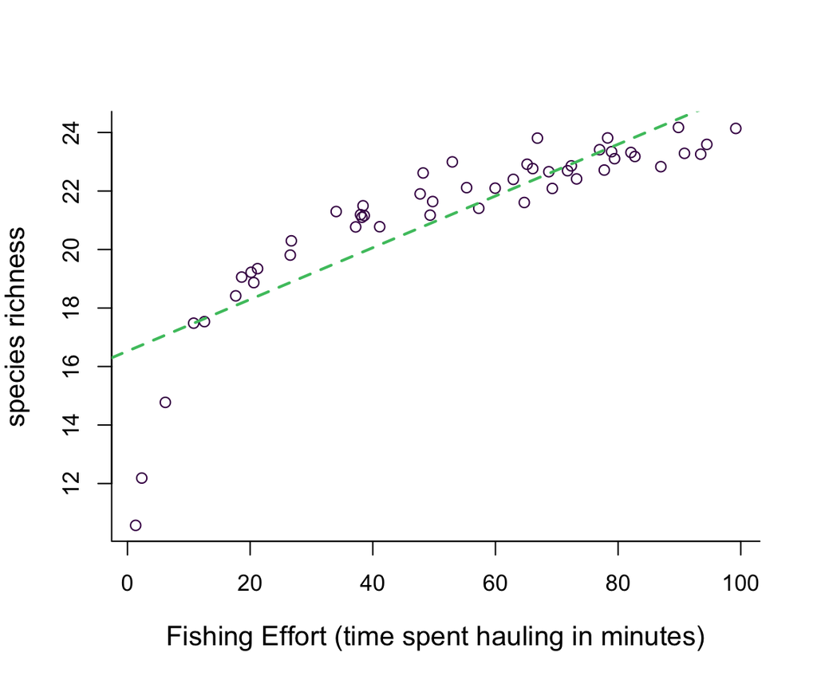

```r
plot(richness ~ effort,
     data = mydata,
     bty = "L",
     cex.lab = 1.2,
     xlab = "Fishing Effort (time spent hauling in minutes)",
     ylab = "species richness",
     col = 1)

# use abline(h=) to add a horizontal line by extracting the intercept
# using coef() on the null.model object.
abline(first.model , col = 6, lty = 2, lwd = 2)
```

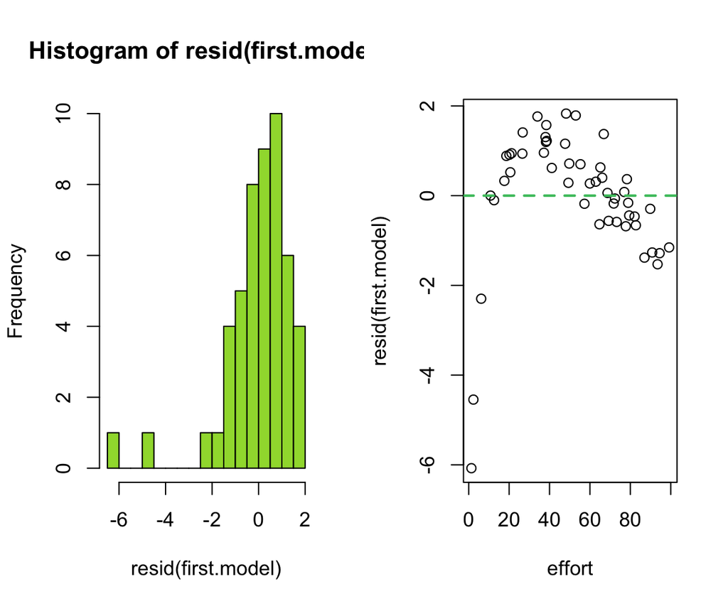

```r
# create a 2-panel plotting window for the diagnostics on the
# residuals
par(mfrow=c(1,2))
# histogram of the residuals...
hist(resid(first.model), 15, col = 7)

# plot of the residuals of the line as a function of effort
plot(resid(first.model) ~ effort, data = mydata)
abline(h = 0 , col = 6, lty = 2, lwd = 2)
```

Again, note the AIC of this fitted model which is 184.1. The residual plots are more helpful to us now, but still they are neither normally distributed, nor randomly scattered either side of the expected line, and show marked pattern with respect to `effort`. On to a second-order polynomial.

## A 2nd order polynomail linear model (a quadratic)

In order to include the square of effort in the model, the easiest thing to do is add a column to our dataset and include this term in our `glm()`.

```r
# add effort squared to the dataframe
mydata$effort.2 <- mydata$effort ^ 2

# now add this term to the glm
second.model <- glm(richness ~ effort + effort.2, data = mydata)

summary(second.model)
```

```
#>
#> Call:
#> glm(formula = richness ~ effort + effort.2, data = mydata)
#>
#> Deviance Residuals:
#>     Min       1Q   Median       3Q      Max
#> -3.4917  -0.4492   0.0240   0.6641   1.5124
#>
#> Coefficients:
#>               Estimate Std. Error t value Pr(>|t|)
#> (Intercept) 13.7339406  0.4575374  30.017  < 2e-16 ***
#> effort       0.2467976  0.0202251  12.203 3.56e-16 ***
#> effort.2    -0.0015842  0.0001959  -8.086 1.90e-10 ***
#> ---
#> Signif. codes:  0 '***' 0.001 '**' 0.01 '*' 0.05 '.' 0.1 ' ' 1
#>
#> (Dispersion parameter for gaussian family taken to be 0.9184801)
#>
#>     Null deviance: 386.981  on 49  degrees of freedom
#> Residual deviance:  43.169  on 47  degrees of freedom
#> AIC: 142.55
#>
#> Number of Fisher Scoring iterations: 2
```

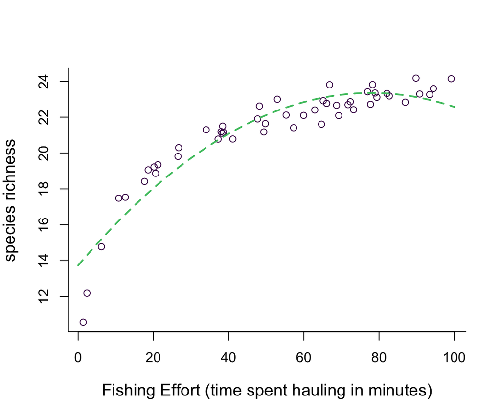

```r
par(mfrow = c(1,1))
plot(richness ~ effort,
     data = mydata,
     bty = "L",
     cex.lab = 1.2,
     xlab = "Fishing Effort (time spent hauling in minutes)",
     ylab = "species richness",
     col = 1)

# Now are a bit stuck. We can no longer use abline to add the model
# predictions as it only works with straight lines. We have
# use the predict function, which will take a bunch of hypothetical
# x values and calculate the corresponding y values based on the
# estimated coefficients we got by fitting our model to our data.
# In order to do this, we need to create a set of dummy effort
# values for which we want to calculate the corresponding estimated
# richness values for plotting a nice curve.

# a sequence of hypothetical effort values from 0 to 100 in steps of 1.
# The smaller we make the step-size, the smoother the curve will appear.
new.effort <- seq(0, 100, 1)

# create a new data.frame object with columns that have the EXACT same
# name as in our original data. We dont need the response value though,
# since we are trying to estimate that using this method!
new.data <- data.frame(effort = new.effort,
                       effort.2 = new.effort ^ 2)

# now predict the richness based on this new data which i call y.hat
# in reference to the mathematical notation of putting an arrow head
# like a hat over predicted values. Here we predict using second.model,
# and pass it the hypothetical effort values to use to make the
# predictions.
y.hat <- predict(second.model, newdata = new.data)

# and finally, add this line to the plot of the data as a function of
# our hypothetical new.effort values
lines(y.hat ~ new.effort, data = mydata, col = 6, lty = 2, lwd =2)
```

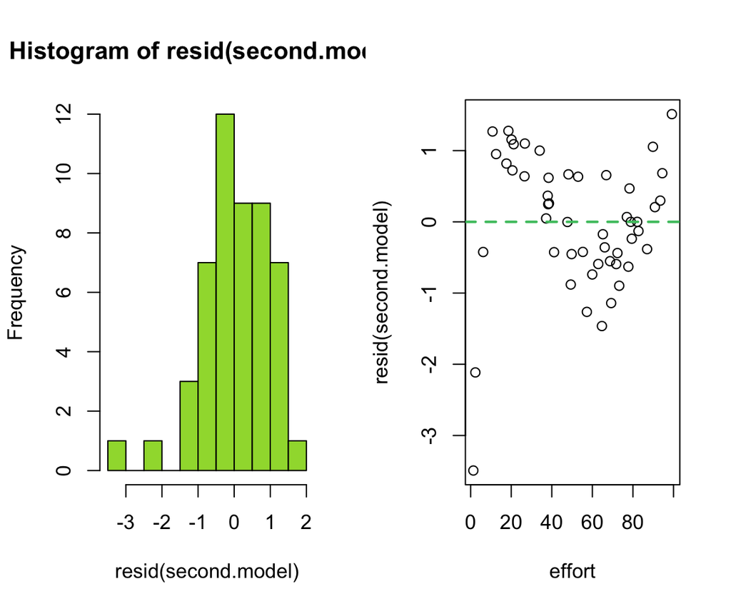

```r
# create a 2-panel plotting window for the diagnostics on the
# residuals
par(mfrow=c(1,2))
# histogram of the residuals...
hist(resid(second.model), 15, col = 7)

# plot of the residuals of the line as a function of effort
plot(resid(second.model) ~ effort, data = mydata)
abline(h = 0 , col = 6, lty = 2, lwd = 2)
```

Again, note the AIC of this fitted model which is 142.5. The residual plots are more helpful to us now. They are pretty well normally distributed and are on the whole closer to zero. But they are still not randomly scattered either side of the expected line, and show marked pattern with respect to `effort`.

## Tasks: fit higher order polynomials

Your tasks for this week are as follows: + fit a series of higher order polynomials, from 3rd to 8th order. There is no need to plot the estimated models or check the residuals for orders 4 and above. But you may like to do this to see what the higher order polynomials look like. In fact, it is entirely possible to write a loop in R that would automate this… but I havent tried, and more often than not its a case of easier said than done, but by all means take up the challenge if you like and we can help you with it. + Compile a table of AIC values for all polynomials from 0 to 8 and make an argument for which polynomial best explains the data.